# Classifying IMDB Movie reviews as good and bad

```python
from __future__ import absolute_import, print_function, division
import tensorflow as tf
import keras
import numpy as np
import warnings
warnings.filterwarnings('ignore')
print (tf.__version__)
```

```
1.2.1
```

## Load the IMDB dataset from Keras

### The datset is preprocessed, mapping words to integers of a dictionary. Only the 10000 most frequently occurring words are retained

```python
imdb = keras.datasets.imdb
(train_data, train_labels), (test_data, test_labels) = imdb.load_data(num_words=10000)
```

```python
print ("Training data:{} Training labels:{}".format(len(train_data), len(train_labels)))
```

```
Training data:25000 Training labels:25000
```

### Print the details or word integers of the first train data sample

```python
print(train_data[0])
```

```
[1, 14, 22, 16, 43, 530, 973, 1622, 1385, 65, 458, 4468, 66, 3941, 4, 173, 36, 256, 5, 25, 100, 43, 838, 112, 50, 670, 2, 9, 35, 480, 284, 5, 150, 4, 172, 112, 167, 2, 336, 385, 39, 4, 172, 4536, 1111, 17, 546, 38, 13, 447, 4, 192, 50, 16, 6, 147, 2025, 19, 14, 22, 4, 1920, 4613, 469, 4, 22, 71, 87,…
```

### Display the number of words in the first and second reviews

```python
print(len(train_data[0]), len(train_data[1]))
```

```
218 189
```

### Store the inverse of the dictionary i.e. word to integer mapping

```python
#A dictionary mapping words to an integer index
word_index = imdb.get_word_index()
#the first indices are reserved
word_index = {k:(v+3) for k,v in word_index.items()}
word_index["<PAD>"] = 0
word_index["<START>"] = 1
word_index["<UNK>"] = 2
word_index["<UNUSED>"] = 3

reverse_word_index = dict([(value, key) for (key, value) in word_index.items()])
def decode_review(text):
    return ' '.join([reverse_word_index.get(i, '?') for i in text])
```

### Get the text of the first training data

```python
print(decode_review(train_data[0]))
```

```
<START> this film was just brilliant casting location scenery story direction everyone's really suited the part they played and you could just imagine being there robert <UNK> is an amazing actor and now the same being director <UNK> father came from the same scottish island as myself so i loved the…
```

## Prepare the Data

#### Need to convert array of integers to tensors to feed to NN.

#### We can prepare data using 2 approaches:

#### 1. 1-hot encoding (This is memory intensive. Matrix of shape num_of_words * num_of_reviews

#### 2. Integer tensor of shape max_length * num_of_reviews

### Create an integer tensor of shape max_length * num_reviews

```python
train_data = keras.preprocessing.sequence.pad_sequences(train_data, value=word_index["<PAD>"], padding = 'post', maxlen=256)
test_data = keras.preprocessing.sequence.pad_sequences(test_data, value=word_index["<PAD>"], padding = 'post', maxlen=256)
```

### Checking length of first and second reviews again

```python
print(len(train_data[0]), len(train_data[1]))
```

```
256 256
```

### Inspect the (now padded) first review

```python
print(train_data[0])
```

```
[   1   14   22   16   43  530  973 1622 1385   65  458 4468   66 3941
    4  173   36  256    5   25  100   43  838  112   50  670    2    9
   35  480  284    5  150    4  172  112  167    2  336  385   39    4
  172 4536 1111   17  546   38   13  447    4  192   50   16    6  147
 2025   19   14   22    4 1920 4613  469    4   22   71   87   12   16
   43  530   38   76   15   13 1247    4   22   17  515   17   12   16
  626   18    2    5   62  386   12    8  316    8  106    5    4 2223
 5244   16  480   66 3785   33    4  130   12   16   38  619    5   25
  124   51   36  135   48   25 1415   33    6   22   12  215   28   77
   52    5   14  407   16   82    2    8    4  107  117 5952   15  256
    4    2    7 3766    5  723   36   71   43  530  476   26  400  317
   46    7    4    2 1029   13  104   88    4  381   15  297   98   32
 2071   56   26  141    6  194 7486   18    4  226   22   21  134  476
   26  480    5  144   30 5535   18   51   36   28  224   92   25  104
    4  226   65   16   38 1334   88   12   16  283    5   16 4472  113
  103   32   15   16 5345   19  178   32    0    0    0    0    0    0
    0    0    0    0    0    0    0    0    0    0    0    0    0    0
    0    0    0    0    0    0    0    0    0    0    0    0    0    0
    0    0    0    0]
```

## Model Details

#### Layer 2: GlobalAveragePooling1D: This layer returns a fixed length output for each example by averaging over the sequence dimension. No parameters are learnt in this layer (simple averaging function)

#### Layer 3: Dense Layer with 16 hidden units: The dense layer follows the formula Wx+b, where W is the weight matrix learnt and b is the bias. Therefore, the total number of parameters learnt here are 16 * 16 + 16 = 272.

#### Layer 4: Dense Layer with 1 output unit with sigmoid activation: The total number of parameters learnt are 1 * 16 + 1 = 17 parameters. The sigmoid activation gives the output in the range of 0 and 1.

```python
vocab_size = 10000

model = keras.Sequential()
model.add(keras.layers.Embedding(vocab_size, 16))
model.add(keras.layers.GlobalAveragePooling1D())
model.add(keras.layers.Dense(16, activation=tf.nn.relu))
model.add(keras.layers.Dense(1, activation=tf.nn.sigmoid))

model.summary()
```

```
_________________________________________________________________
Layer (type)                 Output Shape              Param #
=================================================================
embedding_1 (Embedding)      (None, None, 16)          160000
_________________________________________________________________
global_average_pooling1d_1 ( (None, 16)                0
_________________________________________________________________
dense_1 (Dense)              (None, 16)                272
_________________________________________________________________
dense_2 (Dense)              (None, 1)                 17
=================================================================
Total params: 160,289
Trainable params: 160,289
Non-trainable params: 0
_________________________________________________________________
```

## Loss function and Optimizer

#### The loss function used is binary cross-entropy loss function (Since it is a binary classification and sigmoid activation is used).

```python
model.compile(optimizer='adam', loss='binary_crossentropy', metrics=['acc'])
```

### Creating a Validation set

```python
x_val = train_data[:10000]
partial_x_train = train_data[10000:]

y_val = train_labels[:10000]
partial_y_train = train_labels[10000:]
```

## Train the Model

```python
history = model.fit(partial_x_train, partial_y_train, epochs=40, batch_size=512, validation_data=(x_val, y_val), verbose=1)
```

```
Train on 15000 samples, validate on 10000 samples
```

## Evaluate the Model

```python
result = model.evaluate(test_data, test_labels)
print (result)
```

```
[0.3405383111810684, 0.86964]
```

## Graph of accuracy and loss over time

```python
history_dict = history.history
print (history_dict.keys())
```

```
dict_keys(['val_loss', 'val_acc', 'loss', 'acc'])
```

```python
import matplotlib.pyplot as plt

acc = history_dict['acc']
val_acc = history_dict['val_acc']
loss = history_dict['loss']
val_loss = history_dict['val_loss']

epochs = range(1, len(acc) + 1)

# "bo" is for "blue dot"
plt.plot(epochs, loss, 'bo', label='Training loss')
# b is for "solid blue line"
plt.plot(epochs, val_loss, 'b', label='Validation loss')
plt.title('Training and validation loss')
plt.xlabel('Epochs')
plt.ylabel('Loss')
plt.legend()

plt.show()
```

[output not shown]

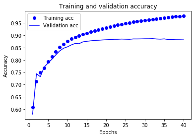

```python
plt.clf()   # clear figure

plt.plot(epochs, acc, 'bo', label='Training acc')
plt.plot(epochs, val_acc, 'b', label='Validation acc')
plt.title('Training and validation accuracy')
plt.xlabel('Epochs')
plt.ylabel('Accuracy')
plt.legend()

plt.show()
```

#### In this plot, the dots represent the training loss and accuracy, and the solid lines are the validation loss and accuracy. Notice the training loss decreases with each epoch and the training accuracy increases with each epoch. This is the functionality of gradient descent. Meanwhile, the validation loss and accuracy remains constant after a certain time. This is because of overfitting.